# Risk Factor Analysis

## Outcome Variable

**Outcome Variable:** whz

## Predictor Variables

**Intervention Variable:** perdiar6

**Adjustment Set:**

- arm
- sex
- W_mage
- meducyrs
- W_mhtcm
- W_mwtkg
- W_mbmi
- W_birthwt
- W_birthlen
- W_nrooms
- month
- brthmon
- impfloor
- impsan
- safeh20
- delta_W_mage
- delta_meducyrs
- delta_W_mhtcm
- delta_W_mwtkg
- delta_W_mbmi
- delta_W_birthwt
- delta_W_birthlen
- delta_W_nrooms
- delta_month
- delta_brthmon
- delta_impfloor
- delta_impsan
- delta_safeh20

## Stratifying Variables

The analysis was stratified on these variable(s):

- agecat
- studyid
- country

## Data Summary

| agecat | studyid | country | perdiar6 | n_cell | n |
| --- | --- | --- | --- | --- | --- |
| Birth | ki0047075b-MAL-ED | BANGLADESH | 0% | 79 | 241 |
| Birth | ki0047075b-MAL-ED | BANGLADESH | (0%, 5%] | 92 | 241 |
| Birth | ki0047075b-MAL-ED | BANGLADESH | >5% | 70 | 241 |
| Birth | ki0047075b-MAL-ED | BRAZIL | 0% | 169 | 183 |
| Birth | ki0047075b-MAL-ED | BRAZIL | (0%, 5%] | 12 | 183 |
| Birth | ki0047075b-MAL-ED | BRAZIL | >5% | 2 | 183 |
| Birth | ki0047075b-MAL-ED | INDIA | 0% | 46 | 203 |
| Birth | ki0047075b-MAL-ED | INDIA | (0%, 5%] | 107 | 203 |
| Birth | ki0047075b-MAL-ED | INDIA | >5% | 50 | 203 |
| Birth | ki0047075b-MAL-ED | NEPAL | 0% | 56 | 168 |
| Birth | ki0047075b-MAL-ED | NEPAL | (0%, 5%] | 57 | 168 |
| Birth | ki0047075b-MAL-ED | NEPAL | >5% | 55 | 168 |
| Birth | ki0047075b-MAL-ED | PERU | 0% | 82 | 279 |
| Birth | ki0047075b-MAL-ED | PERU | (0%, 5%] | 84 | 279 |
| Birth | ki0047075b-MAL-ED | PERU | >5% | 113 | 279 |
| Birth | ki0047075b-MAL-ED | SOUTH AFRICA | 0% | 192 | 250 |
| Birth | ki0047075b-MAL-ED | SOUTH AFRICA | (0%, 5%] | 49 | 250 |
| Birth | ki0047075b-MAL-ED | SOUTH AFRICA | >5% | 9 | 250 |
| Birth | ki0047075b-MAL-ED | TANZANIA, UNITED REPUBLIC OF | 0% | 59 | 118 |
| Birth | ki0047075b-MAL-ED | TANZANIA, UNITED REPUBLIC OF | (0%, 5%] | 40 | 118 |
| Birth | ki0047075b-MAL-ED | TANZANIA, UNITED REPUBLIC OF | >5% | 19 | 118 |
| Birth | ki1000109-ResPak | PAKISTAN | 0% | 0 | 5 |
| Birth | ki1000109-ResPak | PAKISTAN | (0%, 5%] | 2 | 5 |
| Birth | ki1000109-ResPak | PAKISTAN | >5% | 3 | 5 |
| Birth | ki1017093-NIH-Birth | BANGLADESH | 0% | 4 | 26 |
| Birth | ki1017093-NIH-Birth | BANGLADESH | (0%, 5%] | 3 | 26 |
| Birth | ki1017093-NIH-Birth | BANGLADESH | >5% | 19 | 26 |
| Birth | ki1017093c-NIH-Crypto | BANGLADESH | 0% | 6 | 23 |
| Birth | ki1017093c-NIH-Crypto | BANGLADESH | (0%, 5%] | 7 | 23 |
| Birth | ki1017093c-NIH-Crypto | BANGLADESH | >5% | 10 | 23 |

[output cut: 102 more lines]

The following strata were considered:

- agecat: 24 months, studyid: ki0047075b-MAL-ED, country: BANGLADESH
- agecat: 24 months, studyid: ki0047075b-MAL-ED, country: BRAZIL
- agecat: 24 months, studyid: ki0047075b-MAL-ED, country: INDIA
- agecat: 24 months, studyid: ki0047075b-MAL-ED, country: NEPAL
- agecat: 24 months, studyid: ki0047075b-MAL-ED, country: PERU
- agecat: 24 months, studyid: ki0047075b-MAL-ED, country: SOUTH AFRICA
- agecat: 24 months, studyid: ki0047075b-MAL-ED, country: TANZANIA, UNITED REPUBLIC OF
- agecat: 24 months, studyid: ki1017093-NIH-Birth, country: BANGLADESH
- agecat: 24 months, studyid: ki1017093b-PROVIDE, country: BANGLADESH
- agecat: 24 months, studyid: ki1017093c-NIH-Crypto, country: BANGLADESH
- agecat: 24 months, studyid: ki1114097-CMIN, country: BANGLADESH
- agecat: 24 months, studyid: ki1114097-CMIN, country: GUINEA-BISSAU
- agecat: 24 months, studyid: ki1114097-CMIN, country: PERU
- agecat: 24 months, studyid: ki1114097-CONTENT, country: PERU
- agecat: 6 months, studyid: ki0047075b-MAL-ED, country: BANGLADESH
- agecat: 6 months, studyid: ki0047075b-MAL-ED, country: BRAZIL
- agecat: 6 months, studyid: ki0047075b-MAL-ED, country: INDIA
- agecat: 6 months, studyid: ki0047075b-MAL-ED, country: NEPAL
- agecat: 6 months, studyid: ki0047075b-MAL-ED, country: PERU
- agecat: 6 months, studyid: ki0047075b-MAL-ED, country: SOUTH AFRICA
- agecat: 6 months, studyid: ki0047075b-MAL-ED, country: TANZANIA, UNITED REPUBLIC OF
- agecat: 6 months, studyid: ki1000109-ResPak, country: PAKISTAN
- agecat: 6 months, studyid: ki1017093-NIH-Birth, country: BANGLADESH
- agecat: 6 months, studyid: ki1017093b-PROVIDE, country: BANGLADESH
- agecat: 6 months, studyid: ki1017093c-NIH-Crypto, country: BANGLADESH
- agecat: 6 months, studyid: ki1114097-CMIN, country: BANGLADESH
- agecat: 6 months, studyid: ki1114097-CMIN, country: BRAZIL
- agecat: 6 months, studyid: ki1114097-CMIN, country: GUINEA-BISSAU
- agecat: 6 months, studyid: ki1114097-CMIN, country: PERU
- agecat: 6 months, studyid: ki1114097-CONTENT, country: PERU
- agecat: Birth, studyid: ki0047075b-MAL-ED, country: BANGLADESH
- agecat: Birth, studyid: ki0047075b-MAL-ED, country: BRAZIL
- agecat: Birth, studyid: ki0047075b-MAL-ED, country: INDIA
- agecat: Birth, studyid: ki0047075b-MAL-ED, country: NEPAL
- agecat: Birth, studyid: ki0047075b-MAL-ED, country: PERU
- agecat: Birth, studyid: ki0047075b-MAL-ED, country: SOUTH AFRICA
- agecat: Birth, studyid: ki0047075b-MAL-ED, country: TANZANIA, UNITED REPUBLIC OF
- agecat: Birth, studyid: ki1000109-ResPak, country: PAKISTAN
- agecat: Birth, studyid: ki1017093-NIH-Birth, country: BANGLADESH
- agecat: Birth, studyid: ki1017093c-NIH-Crypto, country: BANGLADESH
- agecat: Birth, studyid: ki1114097-CMIN, country: BANGLADESH
- agecat: Birth, studyid: ki1114097-CMIN, country: BRAZIL
- agecat: Birth, studyid: ki1114097-CMIN, country: PERU
- agecat: Birth, studyid: ki1114097-CONTENT, country: PERU

### Dropped Strata

Some strata were dropped due to rare outcomes:

- agecat: Birth, studyid: ki0047075b-MAL-ED, country: BRAZIL
- agecat: Birth, studyid: ki1000109-ResPak, country: PAKISTAN
- agecat: Birth, studyid: ki1017093-NIH-Birth, country: BANGLADESH
- agecat: Birth, studyid: ki1114097-CMIN, country: BANGLADESH
- agecat: Birth, studyid: ki1114097-CMIN, country: PERU
- agecat: Birth, studyid: ki1114097-CONTENT, country: PERU
- agecat: 6 months, studyid: ki0047075b-MAL-ED, country: BRAZIL
- agecat: 24 months, studyid: ki0047075b-MAL-ED, country: BRAZIL

## Methods Detail

We’re interested in the causal parameters $E[Y_a]$ for all values of $a \in \mathcal{A}$. These parameters represent the mean outcome if, possibly contrary to fact, we intervened to set all units to have $A=a$. Under the randomization and positivity assumptions, these are identified by the statistical parameters $\psi_a=E_W[E_{Y|A,W}(Y|A=a,W)]$. In addition, we’re interested in the mean of $Y$, $E[Y]$ under no intervention (the observed mean). We will estimate these parameters by using SuperLearner to fit the relevant likelihood factors – $E_{Y|A,W}(Y|A=a,W)$ and $p(A=a|W)$, and then updating our likelihood fit using a joint TMLE.

For unadjusted analyses ($W=\{\}$), initial likelihoods were estimated using Lrnr_glm to estimate the simple $E(Y|A)$ and Lrnr_mean to estimate $p(A)$. For adjusted analyses, a small library containing Lrnr_glmnet, Lrnr_xgboost, and Lrnr_mean was used.

Having estimated these parameters, we will then use the delta method to estimate relative risks and attributable risks relative to a prespecified baseline level of $A$.

# Results Detail

## Results Plots

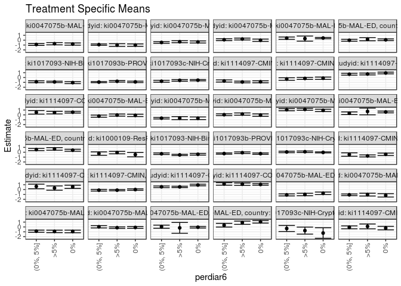

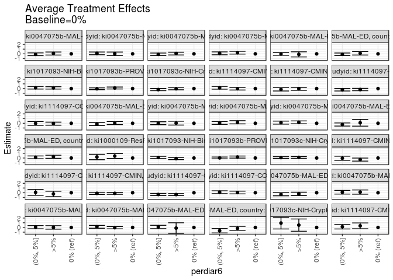

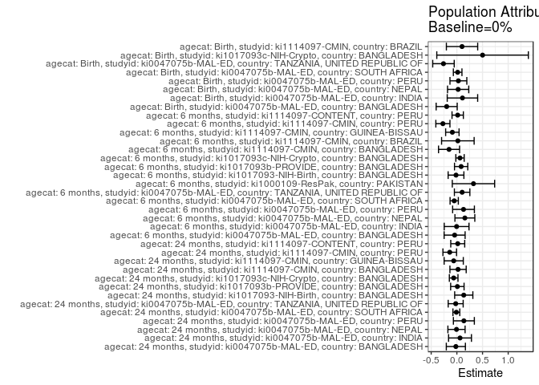

## Results Table

### Parameter: TSM

| agecat | studyid | country | intervention_level | baseline_level | estimate | ci_lower | ci_upper |
| --- | --- | --- | --- | --- | --- | --- | --- |
| Birth | ki0047075b-MAL-ED | BANGLADESH | 0% | NA | -0.7646138 | -1.0206655 | -0.5085621 |
| Birth | ki0047075b-MAL-ED | BANGLADESH | (0%, 5%] | NA | -1.0879537 | -1.2934621 | -0.8824454 |
| Birth | ki0047075b-MAL-ED | BANGLADESH | >5% | NA | -1.0105748 | -1.2651470 | -0.7560025 |
| Birth | ki0047075b-MAL-ED | INDIA | 0% | NA | -1.1777733 | -1.5258813 | -0.8296652 |
| Birth | ki0047075b-MAL-ED | INDIA | (0%, 5%] | NA | -1.0697376 | -1.2452897 | -0.8941855 |
| Birth | ki0047075b-MAL-ED | INDIA | >5% | NA | -1.0342392 | -1.3216409 | -0.7468374 |
| Birth | ki0047075b-MAL-ED | NEPAL | 0% | NA | -0.9293993 | -1.1926904 | -0.6661083 |
| Birth | ki0047075b-MAL-ED | NEPAL | (0%, 5%] | NA | -0.8713271 | -1.0837815 | -0.6588727 |
| Birth | ki0047075b-MAL-ED | NEPAL | >5% | NA | -0.9199643 | -1.1733397 | -0.6665888 |
| Birth | ki0047075b-MAL-ED | PERU | 0% | NA | -0.1034372 | -0.2889438 | 0.0820693 |
| Birth | ki0047075b-MAL-ED | PERU | (0%, 5%] | NA | 0.0343835 | -0.2055809 | 0.2743479 |
| Birth | ki0047075b-MAL-ED | PERU | >5% | NA | -0.1488633 | -0.3140474 | 0.0163208 |
| Birth | ki0047075b-MAL-ED | SOUTH AFRICA | 0% | NA | -0.0568750 | -0.2178610 | 0.1041110 |
| Birth | ki0047075b-MAL-ED | SOUTH AFRICA | (0%, 5%] | NA | 0.0457143 | -0.2756394 | 0.3670679 |
| Birth | ki0047075b-MAL-ED | SOUTH AFRICA | >5% | NA | -0.1888889 | -1.3021928 | 0.9244150 |
| Birth | ki0047075b-MAL-ED | TANZANIA, UNITED REPUBLIC OF | 0% | NA | 1.0541678 | 0.7952193 | 1.3131162 |
| Birth | ki0047075b-MAL-ED | TANZANIA, UNITED REPUBLIC OF | (0%, 5%] | NA | 0.3571927 | -0.0231682 | 0.7375536 |
| Birth | ki0047075b-MAL-ED | TANZANIA, UNITED REPUBLIC OF | >5% | NA | 0.8707969 | 0.5384121 | 1.2031818 |
| Birth | ki1017093c-NIH-Crypto | BANGLADESH | 0% | NA | -1.2516667 | -2.3338692 | -0.1694641 |
| Birth | ki1017093c-NIH-Crypto | BANGLADESH | (0%, 5%] | NA | -0.3185714 | -0.9422112 | 0.3050684 |
| Birth | ki1017093c-NIH-Crypto | BANGLADESH | >5% | NA | -0.7530000 | -1.4736153 | -0.0323847 |
| Birth | ki1114097-CMIN | BRAZIL | 0% | NA | -0.2338480 | -0.5961244 | 0.1284285 |
| Birth | ki1114097-CMIN | BRAZIL | (0%, 5%] | NA | -0.0793138 | -0.3763379 | 0.2177104 |
| Birth | ki1114097-CMIN | BRAZIL | >5% | NA | 0.1112885 | -0.3837986 | 0.6063756 |
| 6 months | ki0047075b-MAL-ED | BANGLADESH | 0% | NA | -0.0960032 | -0.3395975 | 0.1475910 |
| 6 months | ki0047075b-MAL-ED | BANGLADESH | (0%, 5%] | NA | -0.2590980 | -0.4730085 | -0.0451875 |
| 6 months | ki0047075b-MAL-ED | BANGLADESH | >5% | NA | -0.0410055 | -0.2605314 | 0.1785204 |
| 6 months | ki0047075b-MAL-ED | INDIA | 0% | NA | -0.6982700 | -0.9661835 | -0.4303565 |
| 6 months | ki0047075b-MAL-ED | INDIA | (0%, 5%] | NA | -0.6815098 | -0.8353565 | -0.5276631 |
| 6 months | ki0047075b-MAL-ED | INDIA | >5% | NA | -0.6642363 | -0.9733813 | -0.3550914 |

[output cut: 78 more lines]

### Parameter: E(Y)

| agecat | studyid | country | intervention_level | baseline_level | estimate | ci_lower | ci_upper |
| --- | --- | --- | --- | --- | --- | --- | --- |
| Birth | ki0047075b-MAL-ED | BANGLADESH | NA | NA | -0.9630705 | -1.0989132 | -0.8272278 |
| Birth | ki0047075b-MAL-ED | INDIA | NA | NA | -1.0691133 | -1.2078629 | -0.9303637 |
| Birth | ki0047075b-MAL-ED | NEPAL | NA | NA | -0.9044643 | -1.0439568 | -0.7649718 |
| Birth | ki0047075b-MAL-ED | PERU | NA | NA | -0.0735842 | -0.1836203 | 0.0364518 |
| Birth | ki0047075b-MAL-ED | SOUTH AFRICA | NA | NA | -0.0415200 | -0.1860797 | 0.1030397 |
| Birth | ki0047075b-MAL-ED | TANZANIA, UNITED REPUBLIC OF | NA | NA | 0.7932203 | 0.5962220 | 0.9902187 |
| Birth | ki1017093c-NIH-Crypto | BANGLADESH | NA | NA | -0.7508696 | -1.2358912 | -0.2658480 |
| Birth | ki1114097-CMIN | BRAZIL | NA | NA | -0.1332432 | -0.3441055 | 0.0776190 |
| 6 months | ki0047075b-MAL-ED | BANGLADESH | NA | NA | -0.1397960 | -0.2688682 | -0.0107238 |
| 6 months | ki0047075b-MAL-ED | INDIA | NA | NA | -0.7033969 | -0.8285284 | -0.5782654 |
| 6 months | ki0047075b-MAL-ED | NEPAL | NA | NA | 0.1110452 | -0.0202712 | 0.2423616 |
| 6 months | ki0047075b-MAL-ED | PERU | NA | NA | 1.0543956 | 0.9326967 | 1.1760945 |
| 6 months | ki0047075b-MAL-ED | SOUTH AFRICA | NA | NA | 0.5420735 | 0.3899459 | 0.6942011 |
| 6 months | ki0047075b-MAL-ED | TANZANIA, UNITED REPUBLIC OF | NA | NA | 0.5170513 | 0.3872178 | 0.6468847 |
| 6 months | ki1000109-ResPak | PAKISTAN | NA | NA | -0.1683617 | -0.3528233 | 0.0160999 |
| 6 months | ki1017093-NIH-Birth | BANGLADESH | NA | NA | -0.4389101 | -0.5279432 | -0.3498771 |
| 6 months | ki1017093b-PROVIDE | BANGLADESH | NA | NA | -0.2083706 | -0.2927992 | -0.1239419 |
| 6 months | ki1017093c-NIH-Crypto | BANGLADESH | NA | NA | 0.0297622 | -0.0491685 | 0.1086930 |
| 6 months | ki1114097-CMIN | BANGLADESH | NA | NA | -0.5780453 | -0.7226627 | -0.4334279 |
| 6 months | ki1114097-CMIN | BRAZIL | NA | NA | 0.5889815 | 0.3767666 | 0.8011963 |
| 6 months | ki1114097-CMIN | GUINEA-BISSAU | NA | NA | -0.0832589 | -0.1713269 | 0.0048090 |
| 6 months | ki1114097-CMIN | PERU | NA | NA | 0.6708938 | 0.5815040 | 0.7602836 |
| 6 months | ki1114097-CONTENT | PERU | NA | NA | 1.0684318 | 0.9515274 | 1.1853362 |
| 24 months | ki0047075b-MAL-ED | BANGLADESH | NA | NA | -0.8208255 | -0.9429246 | -0.6987264 |
| 24 months | ki0047075b-MAL-ED | INDIA | NA | NA | -0.9522907 | -1.0676596 | -0.8369219 |
| 24 months | ki0047075b-MAL-ED | NEPAL | NA | NA | -0.3764474 | -0.4898516 | -0.2630431 |
| 24 months | ki0047075b-MAL-ED | PERU | NA | NA | 0.1199005 | -0.0000331 | 0.2398341 |
| 24 months | ki0047075b-MAL-ED | SOUTH AFRICA | NA | NA | 0.4267017 | 0.3074751 | 0.5459283 |
| 24 months | ki0047075b-MAL-ED | TANZANIA, UNITED REPUBLIC OF | NA | NA | 0.0500935 | -0.0748234 | 0.1750103 |
| 24 months | ki1017093-NIH-Birth | BANGLADESH | NA | NA | -0.9115790 | -1.0095022 | -0.8136559 |
| 24 months | ki1017093b-PROVIDE | BANGLADESH | NA | NA | -0.8879412 | -0.9708680 | -0.8050144 |
| 24 months | ki1017093c-NIH-Crypto | BANGLADESH | NA | NA | -0.6103502 | -0.7050157 | -0.5156847 |
| 24 months | ki1114097-CMIN | BANGLADESH | NA | NA | -0.8535391 | -0.9644236 | -0.7426546 |
| 24 months | ki1114097-CMIN | GUINEA-BISSAU | NA | NA | -0.2053345 | -0.3365972 | -0.0740718 |
| 24 months | ki1114097-CMIN | PERU | NA | NA | 0.7958060 | 0.6890764 | 0.9025356 |
| 24 months | ki1114097-CONTENT | PERU | NA | NA | 0.5668293 | 0.4302437 | 0.7034148 |

### Parameter: ATE

| agecat | studyid | country | intervention_level | baseline_level | estimate | ci_lower | ci_upper |
| --- | --- | --- | --- | --- | --- | --- | --- |
| Birth | ki0047075b-MAL-ED | BANGLADESH | 0% | 0% | 0.0000000 | 0.0000000 | 0.0000000 |
| Birth | ki0047075b-MAL-ED | BANGLADESH | (0%, 5%] | 0% | -0.3233399 | -0.6523574 | 0.0056776 |
| Birth | ki0047075b-MAL-ED | BANGLADESH | >5% | 0% | -0.2459609 | -0.6072776 | 0.1153557 |
| Birth | ki0047075b-MAL-ED | INDIA | 0% | 0% | 0.0000000 | 0.0000000 | 0.0000000 |
| Birth | ki0047075b-MAL-ED | INDIA | (0%, 5%] | 0% | 0.1080357 | -0.2835333 | 0.4996047 |
| Birth | ki0047075b-MAL-ED | INDIA | >5% | 0% | 0.1435341 | -0.3061142 | 0.5931824 |
| Birth | ki0047075b-MAL-ED | NEPAL | 0% | 0% | 0.0000000 | 0.0000000 | 0.0000000 |
| Birth | ki0047075b-MAL-ED | NEPAL | (0%, 5%] | 0% | 0.0580722 | -0.2789137 | 0.3950581 |
| Birth | ki0047075b-MAL-ED | NEPAL | >5% | 0% | 0.0094351 | -0.3557670 | 0.3746371 |
| Birth | ki0047075b-MAL-ED | PERU | 0% | 0% | 0.0000000 | 0.0000000 | 0.0000000 |
| Birth | ki0047075b-MAL-ED | PERU | (0%, 5%] | 0% | 0.1378207 | -0.1668707 | 0.4425122 |
| Birth | ki0047075b-MAL-ED | PERU | >5% | 0% | -0.0454261 | -0.2945523 | 0.2037002 |
| Birth | ki0047075b-MAL-ED | SOUTH AFRICA | 0% | 0% | 0.0000000 | 0.0000000 | 0.0000000 |
| Birth | ki0047075b-MAL-ED | SOUTH AFRICA | (0%, 5%] | 0% | 0.1025893 | -0.2568334 | 0.4620120 |
| Birth | ki0047075b-MAL-ED | SOUTH AFRICA | >5% | 0% | -0.1320139 | -1.2568970 | 0.9928693 |
| Birth | ki0047075b-MAL-ED | TANZANIA, UNITED REPUBLIC OF | 0% | 0% | 0.0000000 | 0.0000000 | 0.0000000 |
| Birth | ki0047075b-MAL-ED | TANZANIA, UNITED REPUBLIC OF | (0%, 5%] | 0% | -0.6969751 | -1.1623942 | -0.2315560 |
| Birth | ki0047075b-MAL-ED | TANZANIA, UNITED REPUBLIC OF | >5% | 0% | -0.1833708 | -0.6047023 | 0.2379607 |
| Birth | ki1017093c-NIH-Crypto | BANGLADESH | 0% | 0% | 0.0000000 | 0.0000000 | 0.0000000 |
| Birth | ki1017093c-NIH-Crypto | BANGLADESH | (0%, 5%] | 0% | 0.9330952 | -0.3159400 | 2.1821305 |
| Birth | ki1017093c-NIH-Crypto | BANGLADESH | >5% | 0% | 0.4986667 | -0.8015059 | 1.7988393 |
| Birth | ki1114097-CMIN | BRAZIL | 0% | 0% | 0.0000000 | 0.0000000 | 0.0000000 |
| Birth | ki1114097-CMIN | BRAZIL | (0%, 5%] | 0% | 0.1545342 | -0.3162073 | 0.6252756 |
| Birth | ki1114097-CMIN | BRAZIL | >5% | 0% | 0.3451364 | -0.2674873 | 0.9577602 |
| 6 months | ki0047075b-MAL-ED | BANGLADESH | 0% | 0% | 0.0000000 | 0.0000000 | 0.0000000 |
| 6 months | ki0047075b-MAL-ED | BANGLADESH | (0%, 5%] | 0% | -0.1630948 | -0.4862285 | 0.1600390 |
| 6 months | ki0047075b-MAL-ED | BANGLADESH | >5% | 0% | 0.0549977 | -0.2709862 | 0.3809817 |
| 6 months | ki0047075b-MAL-ED | INDIA | 0% | 0% | 0.0000000 | 0.0000000 | 0.0000000 |
| 6 months | ki0047075b-MAL-ED | INDIA | (0%, 5%] | 0% | 0.0167602 | -0.2931720 | 0.3266924 |
| 6 months | ki0047075b-MAL-ED | INDIA | >5% | 0% | 0.0340337 | -0.3733634 | 0.4414307 |

[output cut: 78 more lines]

### Parameter: PAR

| agecat | studyid | country | intervention_level | baseline_level | estimate | ci_lower | ci_upper |
| --- | --- | --- | --- | --- | --- | --- | --- |
| Birth | ki0047075b-MAL-ED | BANGLADESH | 0% | NA | -0.1984567 | -0.4034232 | 0.0065098 |
| Birth | ki0047075b-MAL-ED | INDIA | 0% | NA | 0.1086600 | -0.1877283 | 0.4050483 |
| Birth | ki0047075b-MAL-ED | NEPAL | 0% | NA | 0.0249350 | -0.1816671 | 0.2315372 |
| Birth | ki0047075b-MAL-ED | PERU | 0% | NA | 0.0298530 | -0.1342506 | 0.1939566 |
| Birth | ki0047075b-MAL-ED | SOUTH AFRICA | 0% | NA | 0.0153550 | -0.0683484 | 0.0990584 |
| Birth | ki0047075b-MAL-ED | TANZANIA, UNITED REPUBLIC OF | 0% | NA | -0.2609474 | -0.4702772 | -0.0516176 |
| Birth | ki1017093c-NIH-Crypto | BANGLADESH | 0% | NA | 0.5007971 | -0.3910365 | 1.3926307 |
| Birth | ki1114097-CMIN | BRAZIL | 0% | NA | 0.1006047 | -0.2043113 | 0.4055207 |
| 6 months | ki0047075b-MAL-ED | BANGLADESH | 0% | NA | -0.0437928 | -0.2483210 | 0.1607355 |
| 6 months | ki0047075b-MAL-ED | INDIA | 0% | NA | -0.0051269 | -0.2462890 | 0.2360352 |
| 6 months | ki0047075b-MAL-ED | NEPAL | 0% | NA | 0.1559770 | -0.0375656 | 0.3495197 |
| 6 months | ki0047075b-MAL-ED | PERU | 0% | NA | 0.1295619 | -0.0823999 | 0.3415238 |
| 6 months | ki0047075b-MAL-ED | SOUTH AFRICA | 0% | NA | -0.0517423 | -0.1321802 | 0.0286956 |
| 6 months | ki0047075b-MAL-ED | TANZANIA, UNITED REPUBLIC OF | 0% | NA | 0.1025679 | -0.0480729 | 0.2532086 |
| 6 months | ki1000109-ResPak | PAKISTAN | 0% | NA | 0.3233649 | -0.0891297 | 0.7358595 |
| 6 months | ki1017093-NIH-Birth | BANGLADESH | 0% | NA | -0.0165972 | -0.1701349 | 0.1369405 |
| 6 months | ki1017093b-PROVIDE | BANGLADESH | 0% | NA | 0.0832913 | -0.0459291 | 0.2125116 |
| 6 months | ki1017093c-NIH-Crypto | BANGLADESH | 0% | NA | 0.0609496 | -0.0206096 | 0.1425088 |
| 6 months | ki1114097-CMIN | BANGLADESH | 0% | NA | -0.1522006 | -0.3570786 | 0.0526774 |
| 6 months | ki1114097-CMIN | BRAZIL | 0% | NA | 0.0193731 | -0.2976817 | 0.3364278 |
| 6 months | ki1114097-CMIN | GUINEA-BISSAU | 0% | NA | -0.0878421 | -0.2185577 | 0.0428736 |
| 6 months | ki1114097-CMIN | PERU | 0% | NA | -0.2721974 | -0.4095062 | -0.1348886 |
| 6 months | ki1114097-CONTENT | PERU | 0% | NA | 0.0160116 | -0.0944633 | 0.1264865 |
| 24 months | ki0047075b-MAL-ED | BANGLADESH | 0% | NA | -0.0196416 | -0.2056381 | 0.1663549 |
| 24 months | ki0047075b-MAL-ED | INDIA | 0% | NA | 0.0613821 | -0.1613739 | 0.2841381 |
| 24 months | ki0047075b-MAL-ED | NEPAL | 0% | NA | -0.0072283 | -0.1747315 | 0.1602749 |
| 24 months | ki0047075b-MAL-ED | PERU | 0% | NA | 0.1365172 | -0.0674810 | 0.3405153 |
| 24 months | ki0047075b-MAL-ED | SOUTH AFRICA | 0% | NA | -0.0100215 | -0.0767124 | 0.0566694 |
| 24 months | ki0047075b-MAL-ED | TANZANIA, UNITED REPUBLIC OF | 0% | NA | -0.0229123 | -0.1687596 | 0.1229350 |
| 24 months | ki1017093-NIH-Birth | BANGLADESH | 0% | NA | 0.1344587 | -0.0424565 | 0.3113739 |
| 24 months | ki1017093b-PROVIDE | BANGLADESH | 0% | NA | 0.0096430 | -0.1210284 | 0.1403145 |
| 24 months | ki1017093c-NIH-Crypto | BANGLADESH | 0% | NA | -0.0622286 | -0.1463477 | 0.0218905 |
| 24 months | ki1114097-CMIN | BANGLADESH | 0% | NA | 0.0231491 | -0.1352910 | 0.1815892 |
| 24 months | ki1114097-CMIN | GUINEA-BISSAU | 0% | NA | -0.0613785 | -0.2480219 | 0.1252649 |
| 24 months | ki1114097-CMIN | PERU | 0% | NA | -0.1389739 | -0.2716806 | -0.0062672 |
| 24 months | ki1114097-CONTENT | PERU | 0% | NA | 0.0169647 | -0.1189268 | 0.1528563 |